# `ooacquire` 0.1.1.9002 Algorithms

Pedro J. Aphalo

2017-04-16

## Irradiance

We will step through the different steps of the algorithm used, plotting the spectra at each step along the way. We use raw counts data, included in the package, to make building this vignette easier. At the same time we show how raw data acquire outwith R can be also processed with the package.

## Interactive acquisition of spectral irradiance

We first load the R packages to be used.

```r
library(ggplot2)
library(ggspectra)
library(photobiology)
library(photobiologyWavebands)
library(ooacquire)
library(magrittr)
```

### Household white LED bulb

We will read data from the measurement of the irradiance under a white LED light source—*Osram LED Star classic A 60 E27*. It was measured with a Ocean Optics, Maya 2000 Pro spectrometer, using the function `acquire_irrad_interactive()`. This function saves, to a single file both the raw counts data as a collection of spectra object of class `"raw_mspct"`, and the irradiance spectrum as computed in near-real-time as an object of class `"source_spct"`.

```r
load("white-LED-lamp.Rda")
ls()
```

```
## [1] "LED_lamp04_long.raw_spct" "LED_lamp04_long.spct"
## [3] "dirpath"                  "oldLC"
```

We first print and plot the irradiance spectrum as read from the file.

```r
LED_lamp04_long.spct
```

```
## Object: source_spct [1,421 x 2]
## Wavelength range 251.16 to 898.81 nm, step 0.43 to 0.48 nm
## Label: LED_lamp04_long
## Measured on 2017-04-12 16:34:00 UTC
## Time unit 1s
##
## # A tibble: 1,421 × 2
##    w.length     s.e.irrad
## *     <dbl>         <dbl>
## 1    251.16 -4.840817e-05
## 2    251.63 -3.784879e-05
## 3    252.10 -3.940292e-04
## 4    252.58  9.165484e-05
## 5    253.05  4.335889e-06
## 6    253.53 -2.272898e-05
## 7    254.00  1.366338e-04
## 8    254.48  2.278886e-05
## 9    254.95  1.589077e-05
## 10   255.43 -2.244188e-04
## # ... with 1,411 more rows
```

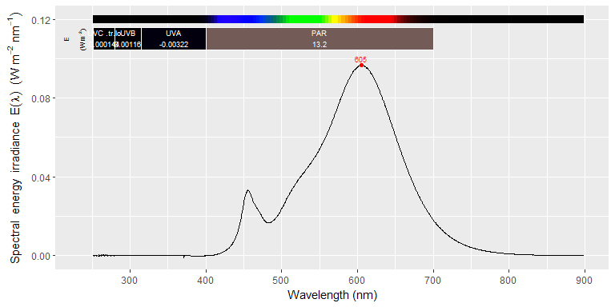

```r
plot(LED_lamp04_long.spct)
```

We next print the collection of spectra containing raw counts data. The protocol used consisted in one light measurement and one dark measurement, each with bracketing of the integration time.

```r
LED_lamp04_long.raw_spct
```

```
## Object: raw_mspct [2 x 1]
## --- Member: light ---
## Object: raw_spct [2,068 x 4]
## Wavelength range 187.82 to 1117.14 nm, step 0.41 to 0.48 nm
## Label: LED_lamp04_long
## Measured on 2017-04-12 16:34:00 UTC
## Data acquired with 'MayaPro2000' s.n. MAYP11278
## grating 'HC1', slit '010s'
## integ. time (s): 1.52, 6, 7.06
## total time (s): 120, 120, 120
## counts @ peak (% of max): 94.2
##
## # A tibble: 2,068 × 4
##    w.length counts_1 counts_2  counts_3
##       <dbl>    <dbl>    <dbl>     <dbl>
## 1    187.82 2301.291  2300.35  2300.765
## 2    188.30 2217.962  2217.80  2218.706
## 3    188.78 2189.101  2189.10  2189.765
## 4    189.26 2189.772  2190.50  2190.294
## 5    189.73 4147.063  9861.40 11354.706
## 6    190.21 4340.177 10680.55 12304.294
## 7    190.69 4322.215 10632.05 12229.353
## 8    191.17 4397.886 10945.40 12610.824
## 9    191.64 4497.089 11321.85 13031.706
## 10   192.12 4368.380 10820.90 12478.353
## # ... with 2,058 more rows
## --- Member: dark ---
## Object: raw_spct [2,068 x 4]
## Wavelength range 187.82 to 1117.14 nm, step 0.41 to 0.48 nm
## Label: LED_lamp04_long
## Measured on 2017-04-12 16:40:24 UTC
## Data acquired with 'MayaPro2000' s.n. MAYP11278
## grating 'HC1', slit '010s'
## integ. time (s): 1.52, 6, 7.06
## total time (s): 120, 120, 120
## counts @ peak (% of max): 94.2
##
## # A tibble: 2,068 × 4
##    w.length counts_1 counts_2  counts_3
##       <dbl>    <dbl>    <dbl>     <dbl>
## 1    187.82 2301.519  2303.60  2303.412
## 2    188.30 2218.430  2218.80  2218.353
## 3    188.78 2189.481  2188.70  2191.412
## 4    189.26 2190.848  2189.95  2191.235
## 5    189.73 4228.076 10177.50 11685.941
## 6    190.21 4426.608 11018.60 12648.471
## 7    190.69 4403.481 10929.25 12563.588
## 8    191.17 4472.797 11229.10 12905.647
## 9    191.64 4585.354 11617.70 13398.941
## 10   192.12 4445.000 11110.90 12798.706
## # ... with 2,058 more rows
##
## --- END ---
```

Ploting the three bracketed spectra shows the raw data. The detector saturates at approximately 64000 counts.

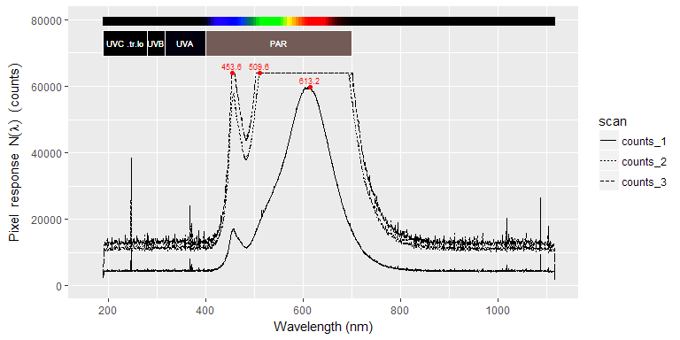

```r
plot(LED_lamp04_long.raw_spct[["light"]])
```

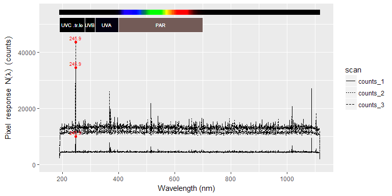

```r
plot(LED_lamp04_long.raw_spct[["dark"]])
```

The first step in the processing is removal of bad pixels, as recorded in the calibration data.

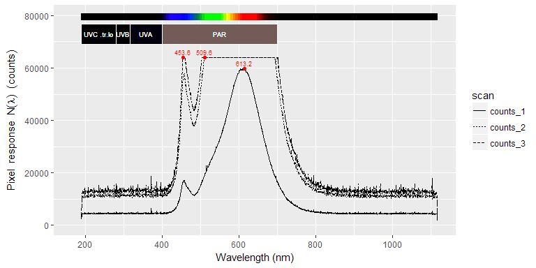

```r
LED_lamp04_long.raw_spct[["light"]] <-
  skip_bad_pixs(LED_lamp04_long.raw_spct[["light"]])
plot(LED_lamp04_long.raw_spct[["light"]])
```

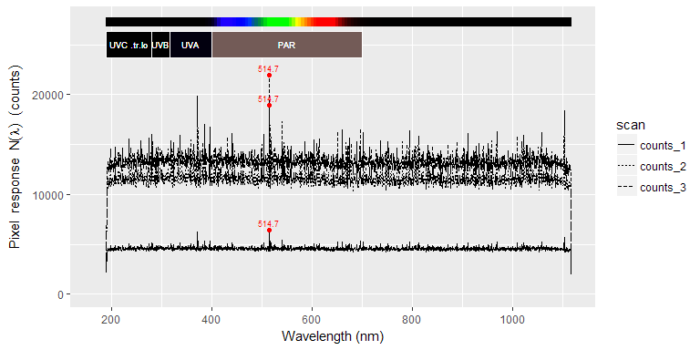

```r
LED_lamp04_long.raw_spct[["dark"]] <-
  skip_bad_pixs(LED_lamp04_long.raw_spct[["dark"]])
plot(LED_lamp04_long.raw_spct[["dark"]])
```

Next step is to replace saturated pixel data, with the missing data marked `NA`.

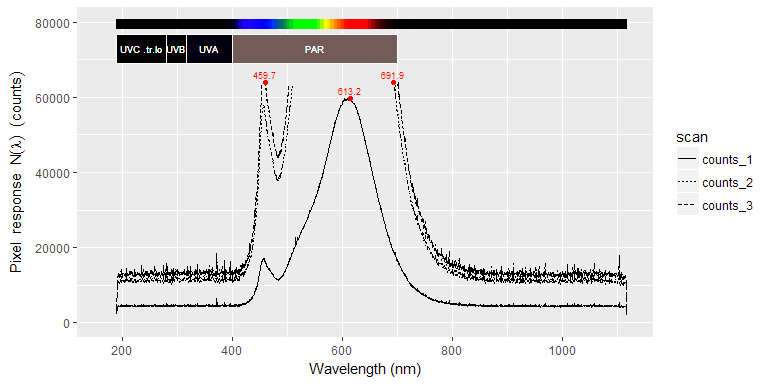

```r
LED_lamp04_long.raw_spct[["light"]] <-
  trim_counts(LED_lamp04_long.raw_spct[["light"]])
plot(LED_lamp04_long.raw_spct[["light"]])
```

Saturated pixels can affect the readings from nearby pixels through charge migration, so we need to also tag as `NA`s these additional pixels.

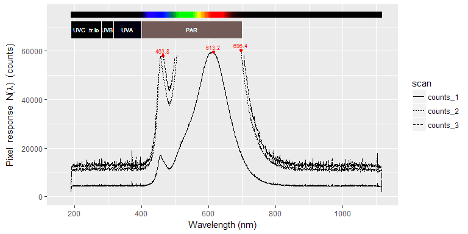

```r
LED_lamp04_long.raw_spct[["light"]] <-
  bleed_nas(LED_lamp04_long.raw_spct[["light"]])
plot(LED_lamp04_long.raw_spct[["light"]])
```

Next we need to apply a linearization function, as detector response is not linear—saturation is gradual.

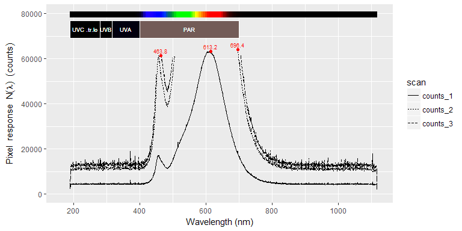

```r
LED_lamp04_long.raw_spct[["light"]] <-
  linearize_counts(LED_lamp04_long.raw_spct[["light"]])
plot(LED_lamp04_long.raw_spct[["light"]])
```

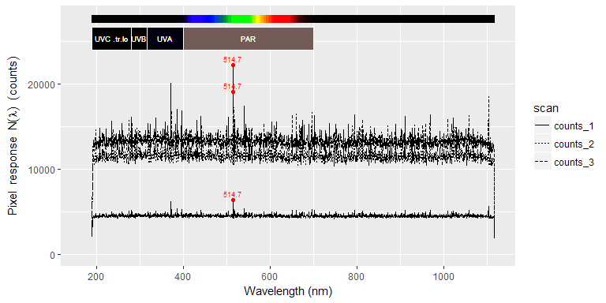

```r
LED_lamp04_long.raw_spct[["dark"]] <-
  linearize_counts(LED_lamp04_long.raw_spct[["dark"]])
plot(LED_lamp04_long.raw_spct[["dark"]])
```

We may next remove an estimate of dark signal based on reference pixels not expected to be exited. This step may apear redundant, but may help in cases when instrument temperature is not stable.

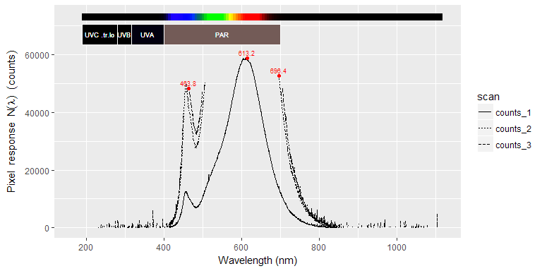

```r
LED_lamp04_long.raw_spct[["light"]] <-
  fshift(LED_lamp04_long.raw_spct[["light"]], range = c(250,290))
plot(LED_lamp04_long.raw_spct[["light"]])
```

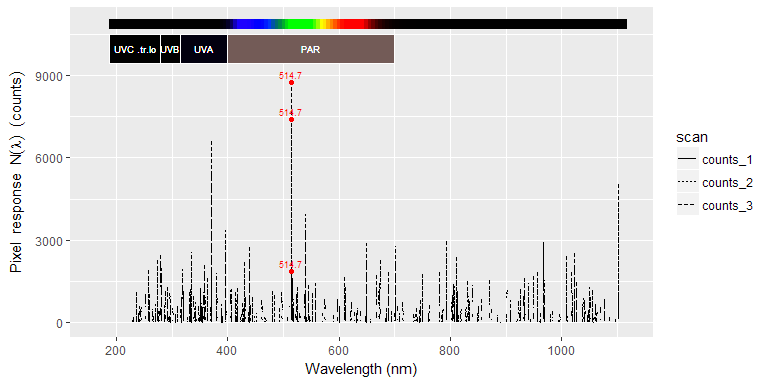

```r
LED_lamp04_long.raw_spct[["dark"]] <-
  fshift(LED_lamp04_long.raw_spct[["dark"]], range = c(250,290))
plot(LED_lamp04_long.raw_spct[["dark"]])
```

Now we can convert the raw counts into counts per second.

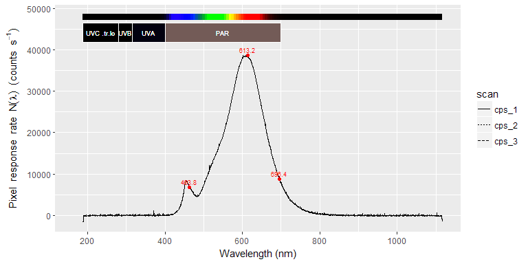

```r
LED_lamp04_long.cps_spct <- cps_mspct()
LED_lamp04_long.cps_spct[["light"]] <-
  raw2cps(LED_lamp04_long.raw_spct[["light"]])
plot(LED_lamp04_long.cps_spct[["light"]])
```

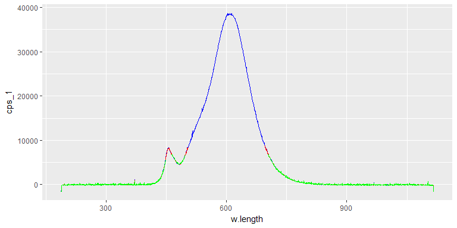

```r
ggplot(LED_lamp04_long.cps_spct[["light"]], aes(x = w.length)) +
  geom_line(aes(y = cps_1), color = "blue") +
  geom_line(aes(y = cps_2), color = "red") +
  geom_line(aes(y = cps_3), color = "green")
```

```r
LED_lamp04_long.cps_spct[["dark"]] <-
  raw2cps(LED_lamp04_long.raw_spct[["dark"]])
```

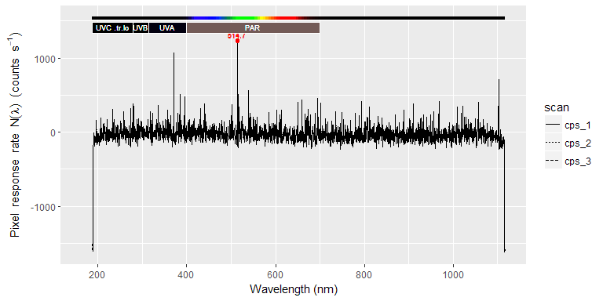

```r
plot(LED_lamp04_long.cps_spct[["dark"]])
```

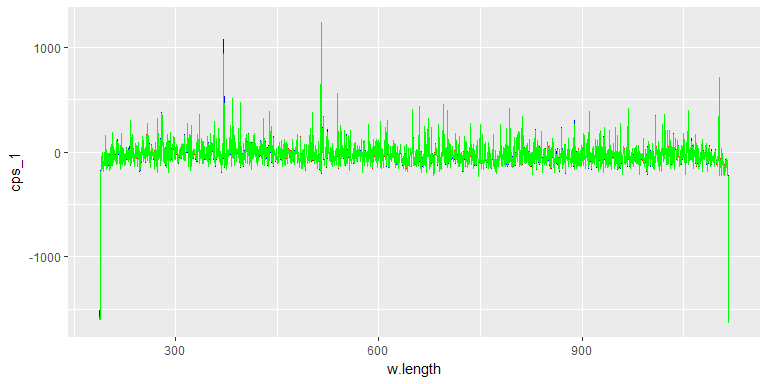

```r
ggplot(LED_lamp04_long.cps_spct[["dark"]], aes(x = w.length)) +
  geom_line(aes(y = cps_1), color = "blue") +
  geom_line(aes(y = cps_2), color = "red") +
  geom_line(aes(y = cps_3), color = "green")
```

Next splicing of the bracketed integrations.

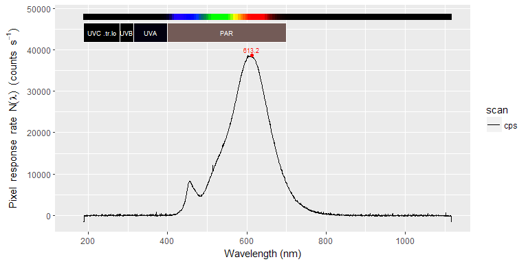

```r
LED_lamp04_long.cps_spct[["light"]] <-
  merge_cps(LED_lamp04_long.cps_spct[["light"]])
plot(LED_lamp04_long.cps_spct[["light"]])
```

```r
LED_lamp04_long.cps_spct[["dark"]] <-
  merge_cps(LED_lamp04_long.cps_spct[["dark"]])
```

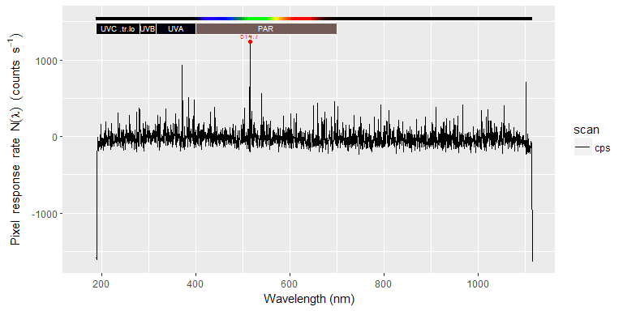

```r
plot(LED_lamp04_long.cps_spct[["dark"]])
```

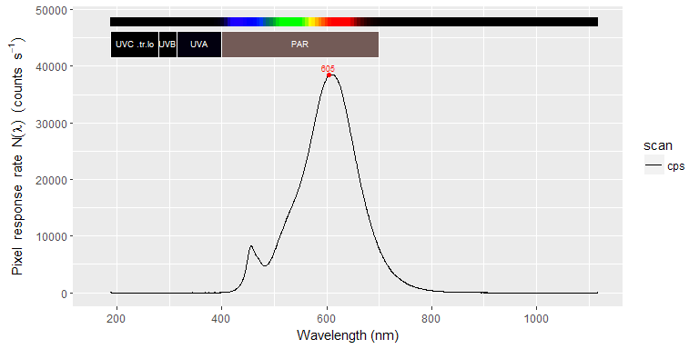

```r
LED_lamp.cps_spct <-
  LED_lamp04_long.cps_spct[["light"]] - LED_lamp04_long.cps_spct[["dark"]]
LED_lamp.cps_spct <-
  copy_attributes(LED_lamp04_long.cps_spct[["light"]],
                  LED_lamp.cps_spct,
                  copy.class = FALSE)
plot(LED_lamp.cps_spct)
```

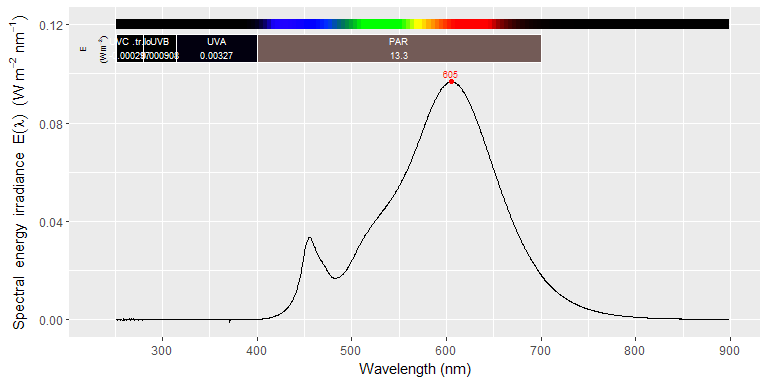

```r
LED_lamp.spct <- cps2irrad(LED_lamp.cps_spct)
plot(LED_lamp.spct)
```

We can finally smooth-out some of the noise.

```r
LED_lamp.spct <- smooth_spct(LED_lamp.spct)
```

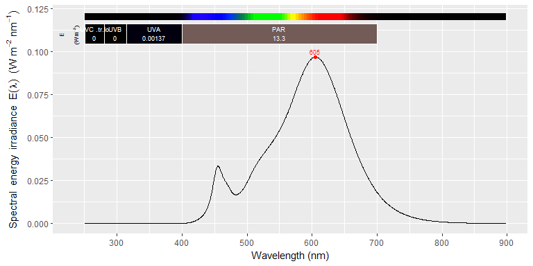

```r
plot(LED_lamp.spct)
```

With an LED source, at least in the case of our Maya 2000 Pro, we do not need to worry about stray light. However, when we measure light sources with a significant emission in the infra-red above 1000 nm, stray light becomes a problem. In addition sources with narrow peaks of emission may benefit from deconvolution of a measured slit function.

### Tungsten halogen lamp

```r
load("halogen-lamp.Rda")
ls()
```

```
## [1] "Halogen.raw_spct"         "Halogen.spct"
## [3] "LED_lamp.cps_spct"        "LED_lamp.spct"
## [5] "LED_lamp04_long.cps_spct" "LED_lamp04_long.raw_spct"
## [7] "LED_lamp04_long.spct"     "dirpath"
## [9] "oldLC"
```

We first print and plot the irradiance spectrum as read from the file.

```r
Halogen.spct
```

```
## Object: source_spct [1,421 x 2]
## Wavelength range 251.16 to 898.81 nm, step 0.43 to 0.48 nm
## Label: Halogen
## Measured on 2017-03-28 11:24:35 UTC
## Time unit 1s
##
## # A tibble: 1,421 × 2
##    w.length    s.e.irrad
## *     <dbl>        <dbl>
## 1    251.16 0.0002660290
## 2    251.63 0.0011004515
## 3    252.10 0.0000478481
## 4    252.58 0.0003799574
## 5    253.05 0.0003379683
## 6    253.53 0.0005571774
## 7    254.00 0.0011422229
## 8    254.48 0.0011303313
## 9    254.95 0.0001980943
## 10   255.43 0.0006559003
## # ... with 1,411 more rows
```

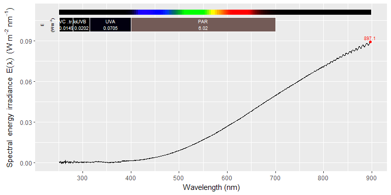

```r
plot(Halogen.spct)
```

```r
Halogen.raw_spct
```

```
## Object: raw_mspct [3 x 1]
## --- Member: light ---
## Object: raw_spct [2,068 x 3]
## Wavelength range 187.82 to 1117.14 nm, step 0.41 to 0.48 nm
## Label: Halogen
## Measured on 2017-03-28 11:24:35 UTC
## Data acquired with 'MayaPro2000' s.n. MAYP11278
## grating 'HC1', slit '010s'
## integ. time (s): 1.86, 7.2
## total time (s): 5.58, 7.2
## counts @ peak (% of max): 94.4
##
## # A tibble: 2,068 × 3
##    w.length counts_1 counts_2
##       <dbl>    <dbl>    <dbl>
## 1    187.82 2288.333     2285
## 2    188.30 2210.000     2211
## 3    188.78 2182.333     2180
## 4    189.26 2181.667     2184
## 5    189.73 3865.000     8578
## 6    190.21 4119.667     9494
## 7    190.69 4114.000     9675
## 8    191.17 4178.667     9918
## 9    191.64 4310.000    10366
## 10   192.12 4189.667     9875
## # ... with 2,058 more rows
## --- Member: filter ---
## Object: raw_spct [2,068 x 3]
## Wavelength range 187.82 to 1117.14 nm, step 0.41 to 0.48 nm
## Label: Halogen
## Measured on 2017-03-28 11:25:54 UTC
## Data acquired with 'MayaPro2000' s.n. MAYP11278
## grating 'HC1', slit '010s'
## integ. time (s): 1.86, 7.2
## total time (s): 5.58, 7.2
## counts @ peak (% of max): 94.4
##
## # A tibble: 2,068 × 3
##    w.length counts_1 counts_2
##       <dbl>    <dbl>    <dbl>
```

[output cut: 23 more lines]

```
##    w.length counts_1 counts_2
##       <dbl>    <dbl>    <dbl>
## 1    187.82 2287.667     2290
## 2    188.30 2211.667     2209
## 3    188.78 2182.667     2185
## 4    189.26 2182.667     2183
## 5    189.73 3816.000     8408
## 6    190.21 4053.667     9346
## 7    190.69 4000.333     9231
## 8    191.17 4062.000     9404
## 9    191.64 4179.667     9863
## 10   192.12 4053.000     9350
## # ... with 2,058 more rows
##
## --- END ---
```

We first use a “pipe” to apply the same initial processing steps as for the LED bulb data in the previous section.

```r
Halogen.cps_spct <- cps_mspct()
for (m in names(Halogen.raw_spct)) {
  Halogen.raw_spct[[m]] %>%
    skip_bad_pixs() %>%
    trim_counts() %>%
    bleed_nas() %>%
    linearize_counts() %>%
    fshift(range = c(200,250)) %>%
    raw2cps() %>%
    merge_cps() -> Halogen.cps_spct[[m]]
}
Halogen.cps_spct
```

```
## Object: cps_mspct [3 x 1]
## --- Member: light ---
## Object: cps_spct [2,068 x 2]
## Wavelength range 187.82 to 1117.14 nm, step 0.41 to 0.48 nm
## Label: Halogen
## Measured on 2017-03-28 11:24:35 UTC
## Data acquired with 'MayaPro2000' s.n. MAYP11278
## grating 'HC1', slit '010s'
## integ. time (s): 1.86, 7.2
## total time (s): 5.58, 7.2
## counts @ peak (% of max): 94.4
```

```
## # A tibble: 2,068 × 2
##    w.length         cps
##       <dbl>       <dbl>
## 1    187.82 -1111.01861
## 2    188.30 -1121.27311
## 3    188.78 -1125.56891
## 4    189.26 -1125.01462
## 5    189.73  -237.41773
## 6    190.21  -109.63694
## 7    190.69   -84.35740
## 8    191.17   -50.40190
## 9    191.64    12.25112
## 10   192.12   -56.41190
## # ... with 2,058 more rows
## --- Member: filter ---
## Object: cps_spct [2,068 x 2]
## Wavelength range 187.82 to 1117.14 nm, step 0.41 to 0.48 nm
## Label: Halogen
## Measured on 2017-03-28 11:25:54 UTC
## Data acquired with 'MayaPro2000' s.n. MAYP11278
## grating 'HC1', slit '010s'
## integ. time (s): 1.86, 7.2
## total time (s): 5.58, 7.2
## counts @ peak (% of max): 94.4
```

```
## # A tibble: 2,068 × 2
##    w.length          cps
##       <dbl>        <dbl>
## 1    187.82 -1143.849494
## 2    188.30 -1154.519721
## 3    188.78 -1158.815521
## 4    189.26 -1158.261224
## 5    189.73  -254.912519
## 6    190.21  -109.498880
## 7    190.69   -91.892270
## 8    191.17   -52.887416
## 9    191.64     4.200022
## 10   192.12   -53.586659
## # ... with 2,058 more rows
## --- Member: dark ---
## Object: cps_spct [2,068 x 2]
## Wavelength range 187.82 to 1117.14 nm, step 0.41 to 0.48 nm
## Label: Halogen
## Measured on 2017-03-28 11:26:36 UTC
## Data acquired with 'MayaPro2000' s.n. MAYP11278
## grating 'HC1', slit '010s'
## integ. time (s): 1.86, 7.2
## total time (s): 5.58, 7.2
## counts @ peak (% of max): 94.4
```

```
## # A tibble: 2,068 × 2
##    w.length         cps
##       <dbl>       <dbl>
## 1    187.82 -1034.84366
## 2    188.30 -1046.06819
## 3    188.78 -1049.39397
## 4    189.26 -1049.67112
## 5    189.73  -185.62401
## 6    190.21   -54.81773
## 7    190.69   -70.86865
## 8    191.17   -46.72093
## 9    191.64    17.39307
## 10   192.12   -54.25936
## # ... with 2,058 more rows
##
## --- END ---
```

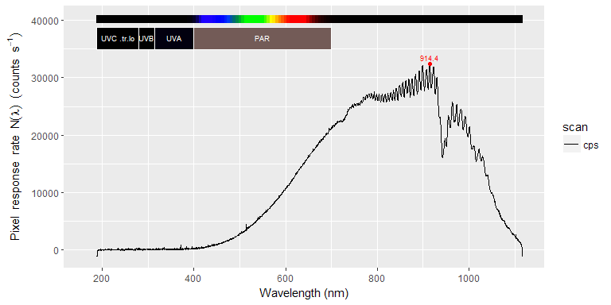

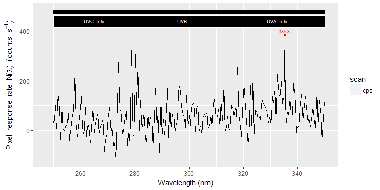

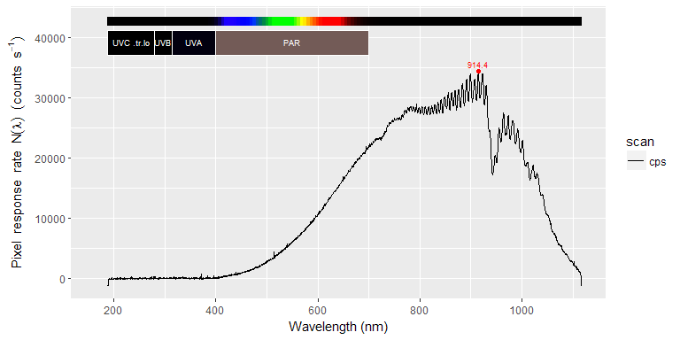

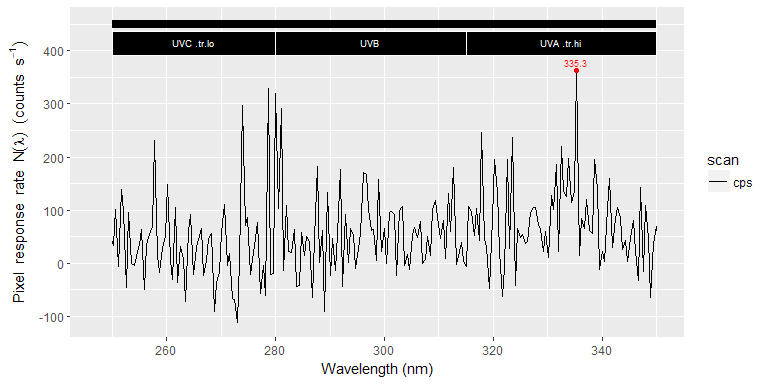

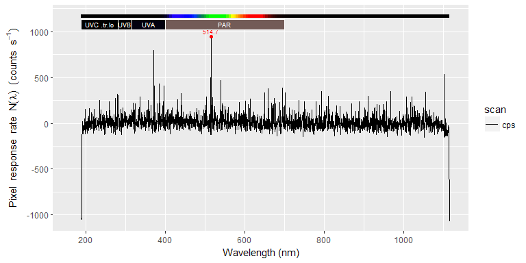

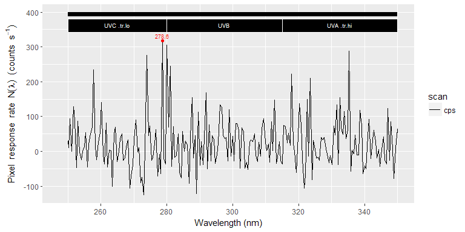

```r
for (m in names(Halogen.cps_spct)) {
  print(plot(Halogen.cps_spct[[m]]))
  print(plot(Halogen.cps_spct[[m]], range = c(250, 350)))
}
```

We substract the dark reading from both the light and filter measurements, and copy attributes, including instrument settings and calibration data.

```r
Halogen01.cps_spct <- cps_mspct()
for (m in setdiff(names(Halogen.cps_spct), "dark")) {
  Halogen01.cps_spct[[m]] <- Halogen.cps_spct[[m]] - Halogen.cps_spct[["dark"]]
  Halogen01.cps_spct[[m]] <-
    copy_attributes(Halogen.cps_spct[[m]],
                    Halogen01.cps_spct[[m]],
                    copy.class = FALSE)
}
Halogen01.cps_spct
```

```
## Object: cps_mspct [2 x 1]
## --- Member: light ---
## Object: cps_spct [2,068 x 2]
## Wavelength range 187.82 to 1117.14 nm, step 0.41 to 0.48 nm
## Label: Halogen
## Measured on 2017-03-28 11:24:35 UTC
## Data acquired with 'MayaPro2000' s.n. MAYP11278
## grating 'HC1', slit '010s'
## integ. time (s): 1.86, 7.2
## total time (s): 5.58, 7.2
## counts @ peak (% of max): 94.4
```

```
## # A tibble: 2,068 × 2
##    w.length        cps
##       <dbl>      <dbl>
## 1    187.82 -76.174949
## 2    188.30 -75.204927
## 3    188.78 -76.174946
## 4    189.26 -75.343502
## 5    189.73 -51.793724
## 6    190.21 -54.819210
## 7    190.69 -13.488755
## 8    191.17  -3.680968
## 9    191.64  -5.141958
## 10   192.12  -2.152541
## # ... with 2,058 more rows
## --- Member: filter ---
## Object: cps_spct [2,068 x 2]
## Wavelength range 187.82 to 1117.14 nm, step 0.41 to 0.48 nm
## Label: Halogen
## Measured on 2017-03-28 11:25:54 UTC
## Data acquired with 'MayaPro2000' s.n. MAYP11278
## grating 'HC1', slit '010s'
## integ. time (s): 1.86, 7.2
## total time (s): 5.58, 7.2
## counts @ peak (% of max): 94.4
```

```
## # A tibble: 2,068 × 2
##    w.length          cps
##       <dbl>        <dbl>
## 1    187.82 -109.0058307
## 2    188.30 -108.4515338
## 3    188.78 -109.4215531
## 4    189.26 -108.5901083
## 5    189.73  -69.2885135
## 6    190.21  -54.6811528
## 7    190.69  -21.0236209
## 8    191.17   -6.1664834
## 9    191.64  -13.1930505
## 10   192.12    0.6727022
## # ... with 2,058 more rows
##
## --- END ---
```